# 2_Classification_Trees_Titanic

## Classification Tree Approach

Here, I apply a classification tree approach to this dataset instead of logistic regression. We first import and process the data in a similar way as we did before. m

```python
%matplotlib inline
import pandas as pd
import matplotlib.pyplot as plt
import numpy as np
from sklearn import tree
```

```python
pdDataFrame = pd.read_csv('train.csv')
```

```python
pdDataFrame["isMale"] = pdDataFrame["Sex"] == "male"
embarkArray = np.zeros(pdDataFrame.shape[0])
for x, EmbkCode in enumerate(['S','C','Q']):
     embarkArray[ pdDataFrame['Embarked'] == EmbkCode ] = x

pdDataFrame["embarkment"] = embarkArray
```

First, let's fit a basic tree first just to play with the data

```python
Y = pd.DataFrame(pdDataFrame, columns = ["Survived"])
X = pd.DataFrame(pdDataFrame,columns=["Pclass","isMale","Age","Parch","Fare","embarkment"])
```

Some of the age data is missing. What to do about this? Let's get rid of this at first and just see if we can get our classifier going.

```python
Xf = X[~X.Age.isnull()]
Yf = Y[~X.Age.isnull()]
```

```python
clf =  tree.DecisionTreeClassifier()
clf.fit(Xf,Yf)
```

```
DecisionTreeClassifier(class_weight=None, criterion='gini', max_depth=None,
            max_features=None, max_leaf_nodes=None,
            min_impurity_decrease=0.0, min_impurity_split=None,
            min_samples_leaf=1, min_samples_split=2,
            min_weight_fraction_leaf=0.0, presort=False, random_state=None,
            splitter='best')
```

```python
yPredict = clf.predict(Xf)
```

```python
Accuracy = np.sum(yPredict == Yf["Survived"] ) / Yf.shape[0]
```

```python
print("Accuracy of %2.2f" % Accuracy)
```

```
Accuracy of 0.98
```

# Imputation of Missing Age Values

The model doesn't know what to do with the NaN values in AGE. Let's make a submodel that is a linear regression predicting AGE from Fare and Class (and embark location while we're at it). We can use this to impute Ages for the ones that are missing.

```python
Xf.head(5)
```

|  | Pclass | isMale | Age | Parch | Fare | embarkment |
| --- | --- | --- | --- | --- | --- | --- |
| 0 | 3 | True | 22.0 | 0 | 7.2500 | 0.0 |
| 1 | 1 | False | 38.0 | 0 | 71.2833 | 1.0 |
| 2 | 3 | False | 26.0 | 0 | 7.9250 | 0.0 |
| 3 | 1 | False | 35.0 | 0 | 53.1000 | 0.0 |
| 4 | 3 | True | 35.0 | 0 | 8.0500 | 0.0 |

```python
YfAge = pd.DataFrame(Xf, columns = ["Age"])
XfAge = pd.DataFrame(Xf, columns=["isMale", "Fare", "Pclass","embarkment"])
```

```python
XfAge.head(5)
```

|  | isMale | Fare | Pclass | embarkment |
| --- | --- | --- | --- | --- |
| 0 | True | 7.2500 | 3 | 0.0 |
| 1 | False | 71.2833 | 1 | 1.0 |
| 2 | False | 7.9250 | 3 | 0.0 |
| 3 | False | 53.1000 | 1 | 0.0 |
| 4 | True | 8.0500 | 3 | 0.0 |

```python
from sklearn import linear_model
```

```python
lm = linear_model.LinearRegression()
lm.fit(XfAge,YfAge)
```

```
LinearRegression(copy_X=True, fit_intercept=True, n_jobs=1, normalize=False)
```

```
Coefficients:
 [[ 4.23243831 -0.03741094 -8.08949158 -0.05829348]]
Mean squared error: 174.41
Variance score: 0.17
```

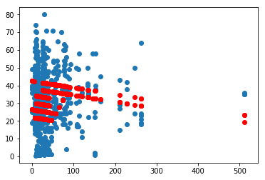

```python
from sklearn.metrics import mean_squared_error, r2_score
age_predict = lm.predict(XfAge)
print('Coefficients: \n', lm.coef_)
# The mean squared error
print("Mean squared error: %.2f"
      % mean_squared_error(YfAge["Age"], age_predict))
# Explained variance score: 1 is perfect prediction
print('Variance score: %.2f' % r2_score(YfAge["Age"], age_predict))
plt.scatter(XfAge["Fare"],YfAge["Age"])
plt.scatter(XfAge["Fare"],age_predict,color="red")
```

# Classification Tree with Ages Predicted via Linear Model

```python
Xm = X[X.Age.isnull()]
Xm_predictors = pd.DataFrame(Xm, columns=["isMale", "Fare", "Pclass","embarkment"])
pAge = lm.predict(Xm_predictors)
```

```python
X.loc[X.Age.isnull(),"Age"] = pAge
```

```python
clf2 =  tree.DecisionTreeClassifier()
clf2.fit(X,Y)
```

```
DecisionTreeClassifier(class_weight=None, criterion='gini', max_depth=None,
            max_features=None, max_leaf_nodes=None,
            min_impurity_decrease=0.0, min_impurity_split=None,
            min_samples_leaf=1, min_samples_split=2,
            min_weight_fraction_leaf=0.0, presort=False, random_state=None,
            splitter='best')
```

```python
#OK Let's try a cross-validation strategy here using scikit-learn
from sklearn.model_selection import KFold
from sklearn.metrics import confusion_matrix

kf = KFold(n_splits=5)
for train, test in kf.split(X):
    clf2.fit(X.loc[train],Y.loc[train])
    yPred = clf2.predict(X.loc[test])
    cmat = confusion_matrix(Y.loc[test],yPred)
    accuracy = np.trace(cmat)/np.sum(cmat)
    print("Accuracy for test was %2.2f" % accuracy)
```

```
Accuracy for test was 0.74
Accuracy for test was 0.78
Accuracy for test was 0.78
Accuracy for test was 0.74
Accuracy for test was 0.79
```

What does our tree look like? We'll use graphviz to visualize it.

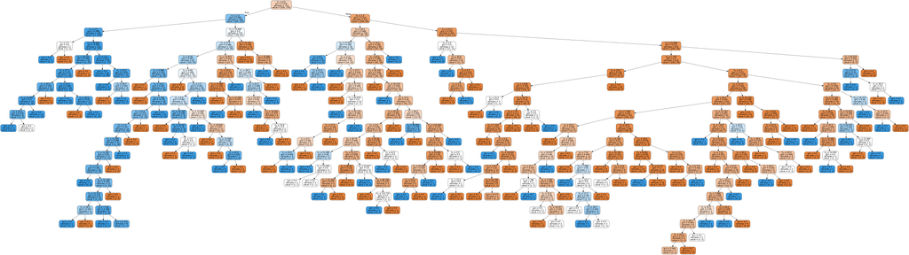

```python
from sklearn.externals.six import StringIO
from IPython.display import Image
from sklearn.tree import export_graphviz
import pydotplus

dot_data = StringIO()

export_graphviz(clf2, out_file=dot_data,
                filled=True, rounded=True,
                special_characters=True)

graph = pydotplus.graph_from_dot_data(dot_data.getvalue())
Image(graph.create_png())
```

OK. It looks like our tree is a *bit* complicated. We need to prune it back to prevent overfitting. m

```
Accuracy for test was 0.80
Accuracy for test was 0.81
Accuracy for test was 0.81
Accuracy for test was 0.77
Accuracy for test was 0.83
Mean cross-validation accuracy was 0.80
```

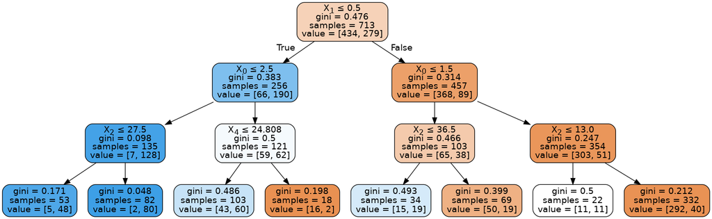

```python
clf2 =  tree.DecisionTreeClassifier(max_depth=3, min_samples_leaf=5)
clf2.fit(X,Y)

kf = KFold(n_splits=5)
mean_accuracy = 0
for train, test in kf.split(X):
    clf2.fit(X.loc[train],Y.loc[train])
    yPred = clf2.predict(X.loc[test])
    cmat = confusion_matrix(Y.loc[test],yPred)
    accuracy = np.trace(cmat)/np.sum(cmat)
    mean_accuracy += accuracy/5
    print("Accuracy for test was %2.2f" % accuracy)

print("Mean cross-validation accuracy was %2.2f" % mean_accuracy)
dot_data = StringIO()

export_graphviz(clf2, out_file=dot_data,
                filled=True, rounded=True,
                special_characters=True)

graph = pydotplus.graph_from_dot_data(dot_data.getvalue())
Image(graph.create_png())
```

#### By playing with the max-depth parameters, I determined that depth=3 was the least depth that I could get away with while maintaining the same overall level of cross-validation accuracy (which is roughly 80%)

```python
#refit our model to all of the data and assess accuracy on test data
clf2.fit(X,Y)
testdata = pd.read_csv("test.csv")
```

```python
testdata["isMale"] = testdata["Sex"] == "male"
embarkArray = np.zeros(testdata.shape[0])
for x, EmbkCode in enumerate(['S','C','Q']):
     embarkArray[ testdata['Embarked'] == EmbkCode ] = x

testdata["embarkment"] = embarkArray
```

```python
Yt = pd.DataFrame(testdata, columns = ["Survived"])
Xt = pd.DataFrame(testdata,columns=["Pclass","isMale","Age","Parch","Fare","embarkment"])
```

```python
Xt.head(5)
```

|  | Pclass | isMale | Age | Parch | Fare | embarkment |
| --- | --- | --- | --- | --- | --- | --- |
| 0 | 3 | True | 34.5 | 0 | 7.8292 | 2.0 |
| 1 | 3 | False | 47.0 | 0 | 7.0000 | 0.0 |
| 2 | 2 | True | 62.0 | 0 | 9.6875 | 2.0 |
| 3 | 3 | True | 27.0 | 0 | 8.6625 | 0.0 |
| 4 | 3 | False | 22.0 | 1 | 12.2875 | 0.0 |

```python
np.where(np.sum(Xt.isnull(), axis=1) == 1)
```

```
(array([ 10,  22,  29,  33,  36,  39,  41,  47,  54,  58,  65,  76,  83,
         84,  85,  88,  91,  93, 102, 107, 108, 111, 116, 121, 124, 127,
        132, 133, 146, 148, 151, 152, 160, 163, 168, 170, 173, 183, 188,
        191, 199, 200, 205, 211, 216, 219, 225, 227, 233, 243, 244, 249,
        255, 256, 265, 266, 267, 268, 271, 273, 274, 282, 286, 288, 289,
        290, 292, 297, 301, 304, 312, 332, 339, 342, 344, 357, 358, 365,
        366, 380, 382, 384, 408, 410, 413, 416, 417]),)
```

```python
Xt.loc[152]
```

```
Pclass           3
isMale        True
Age           60.5
Parch            0
Fare           NaN
embarkment       0
Name: 152, dtype: object
```

One fare is missing. WTF. 30 seems like a reasonable, but random value to put in.

```python
Xt.loc[152,"Fare"] = 30
```

```
Coefficients:
 [[ 3.59328076 -0.01589628 -7.84605346  0.5063161 ]]
Mean squared error: 169.24
Variance score: 0.18
```

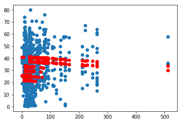

```python
Xn = pd.DataFrame(pdDataFrame,columns=["Pclass","isMale","Age","Parch","Fare","embarkment"])
#gets rid of imputed values and starts fresh
XAll = pd.concat([Xn,Xt])
xA = XAll[~XAll.Age.isnull()]
YfAge = pd.DataFrame(xA, columns = ["Age"])
XfAge = pd.DataFrame(xA, columns=["isMale", "Fare", "Pclass","embarkment"])

lm.fit(XfAge,YfAge)

age_predict = lm.predict(XfAge)

print('Coefficients: \n', lm.coef_)
# The mean squared error
print("Mean squared error: %.2f"
      % mean_squared_error(YfAge["Age"], age_predict))
# Explained variance score: 1 is perfect prediction
print('Variance score: %.2f' % r2_score(YfAge["Age"], age_predict))
plt.scatter(XfAge["Fare"],YfAge["Age"])
plt.scatter(XfAge["Fare"],age_predict,color="red")
```

```python
Xm = Xt[Xt.Age.isnull()]
Xm_predictors = pd.DataFrame(Xm, columns=["isMale", "Fare", "Pclass","embarkment"])
test_age_prediction = lm.predict(Xm_predictors)
Xt.loc[Xt.Age.isnull(),"Age"] = np.round(test_age_prediction)
```

```python
testprediction = clf2.predict(Xt)
```

```python
outStream = open("Survival_Prediction_CART.csv",'w')
outStream.write("PassengerId,Survived\n")
for r,p in enumerate(testprediction):
    outStream.write(",".join([str(r+892), str(p)])+"\n")

outStream.close()
```

# CART Result

This scored a 78.9% on the website, which was a bit better than my logistic regression result! Interestingly, this is closs to our cross-validation result which suggests that reducing maxdepth dealt well with overfit. Now, let's see if using a Random Forest can do even better.

```python
from sklearn.ensemble import RandomForestClassifier
rf = RandomForestClassifier(n_estimators = 1000, criterion = "entropy", max_depth=2, max_leaf_nodes=5)

kf = KFold(n_splits=5)
mean_accuracy = 0

for train, test in kf.split(X):
    rf.fit(X.loc[train],Y.loc[train,"Survived"])
    yPred = rf.predict(X.loc[test])
    cmat = confusion_matrix(Y.loc[test],yPred)
    accuracy = np.trace(cmat)/np.sum(cmat)
    mean_accuracy += accuracy/5
    print("Accuracy for test was %2.2f" % accuracy)

print("Mean cross-validation accuracy was %2.2f" % mean_accuracy)
```

```
Accuracy for test was 0.78
Accuracy for test was 0.79
Accuracy for test was 0.83
Accuracy for test was 0.76
Accuracy for test was 0.83
Mean cross-validation accuracy was 0.80
```

This seemed to put out the same range of using the cross-validation accuracy as the simple CART model, even after playing with the parameters. Depth=2 seemed to also produc around 80% cross-validation accuracy, so I went with that value, again to fight overfit.

```python
rf.fit(X,Y["Survived"])
```

```
RandomForestClassifier(bootstrap=True, class_weight=None, criterion='entropy',
            max_depth=2, max_features='auto', max_leaf_nodes=5,
            min_impurity_decrease=0.0, min_impurity_split=None,
            min_samples_leaf=1, min_samples_split=2,
            min_weight_fraction_leaf=0.0, n_estimators=1000, n_jobs=1,
            oob_score=False, random_state=None, verbose=0,
            warm_start=False)
```

```python
rf_test_prediction = rf.predict(Xt)
outStream = open("Survival_Prediction_CART_RandomForest.csv",'w')
outStream.write("PassengerId,Survived\n")
for r,p in enumerate(rf_test_prediction):
    outStream.write(",".join([str(r+892), str(p)])+"\n")

outStream.close()
```

# Random Forest Result

The random forest model with depth=2 did worse than the single classification tree (77.5% accuracy). Change the depth back to 3 didn't seem to affect the result of the random forest prediction and had the same accuracy. Increasing depth to 5 reduced accuracy to 77%, which suggests more overfitting.